# Punto 1° Parcial: Ajuste de un modelo de R.L.S

Universidad Nacional de Colombia Analisís de Regresión 2022-1S Medellín, Colombia 2022

Daniel Villa 1005087556

Juan Pablo Vanegas 1000640165

[figure not shown]

# Objetivos

Crear un modelo ajustado de R.L.S. por el cual predecimos el peso de los huevos (de gallina) por medio de la altura o el diámetro de este utilizando el software estadístico *R*

## Objetivos específicos

# Antecedentes Relevantes

Utilizando un *pie de rey o calibre* tomamos los datos de una cubeta de huevos tipo AA Marca kikes.

Gracias a que las empresas que distribuyen y producen los huevos, tienen muy controlados el peso, altura y diámetro por los controles de calidad, se esperan unos rangos de variabilidad angostos, esto se nota en este experimento pues al ser todos huevos de un mismo tipo y una misma marca se nota el control sobre ellos.

# Variables de respuesta:

En nuestro caso será el **peso** para ajustar un modelo para predecir por medio de nuestra variable predictora el peso de un huevo.

# Variable de Control:

Ya que haremos dos modelos tendremos dos variables de control; sin relacionarse entre ellas, es decir, serán dos R.L.S.

- 1er caso: Altura
- 2do Caso: Ancho

# Ajuste del modelo

Antes de observar o crear un modelo dado unos puntos, primero haremos un test de correlación de los datos para estudiar el grado de variación conjunta entre el diámetro y peso de los huevos:

```
##
##  Pearson's product-moment correlation
##
## data:  datos$diametro and datos$peso
## t = 5.1667, df = 28, p-value = 1.758e-05
## alternative hypothesis: true correlation is not equal to 0
## 95 percent confidence interval:
##  0.4521558 0.8459674
## sample estimates:
##       cor
## 0.6986211
```

Como podemos ver se rechaza $H_0$ ya que el $p-valor < 0.05$, es decir nuestros datos peso y el diámetro de los huevos tomados no tienen una correlación no significativa, más bien tienen una correlación positiva entre los datos, que vamos a ver por medio de un gráfico de dispersión:

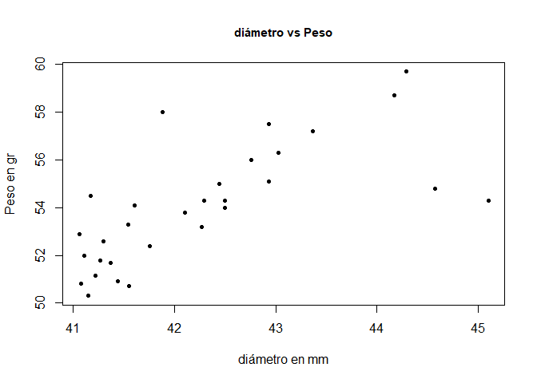

Como podemos ver los datos si tienen en algún grado una correlación positiva (mientras aumentan los valores del diámetro aumenta el peso) a priori.

Una vez visto que existe relación entre las variables pasamos a realizar el ajuste del modelo. Para ello usamos la función `lm()` que toma la forma:

```
##
## Call:
## lm(formula = peso ~ diametro, data = datos)
##
## Residuals:
##     Min      1Q  Median      3Q     Max
## -4.1037 -0.9563  0.0118  1.0663  4.5359
##
## Coefficients:
##             Estimate Std. Error t value Pr(>|t|)
## (Intercept) -10.7807    12.5511  -0.859    0.398
## diametro      1.5340     0.2969   5.167 1.76e-05 ***
## ---
## Signif. codes:  0 '***' 0.001 '**' 0.01 '*' 0.05 '.' 0.1 ' ' 1
##
## Residual standard error: 1.81 on 28 degrees of freedom
## Multiple R-squared:  0.4881, Adjusted R-squared:  0.4698
## F-statistic:  26.7 on 1 and 28 DF,  p-value: 1.758e-05
```

Como podemos ver nuestro intercepto dado el $p-valor > 0.05$ decimos que el intercepto tengan valor a cero, esto es lógico ya que sería extraño encontrar huevos con diámetro cero y un valor de peso inicial.

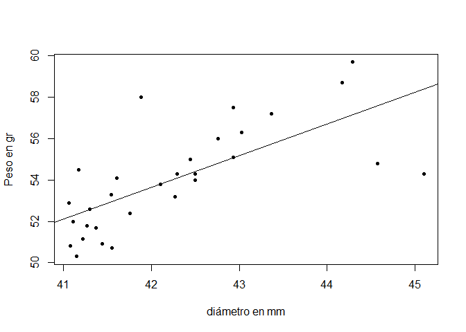

En primer lugar deseamos obtener los estimadores puntuales, errores estándar y p-valores asociados con cada coeficiente

```
##              Estimate Std. Error   t value     Pr(>|t|)
## (Intercept) -10.78066 12.5510919 -0.858942 3.976665e-01
## diametro      1.53402  0.2969033  5.166734 1.758177e-05
```

El resultado del ajuste es:

`(12.5510919)` `(0.2969033)`

$Peso \ = \ 0 + 1.53402*diámetro$

## Intervalos de Confianza

Obtenemos los correspondientes intervalos de confianza para el parámetro $m$ de nuestras modelo = $Y = 0+m*X$ con nivel significación al 95%

| Parámetro | 2.5 % | 97.5 % |
| --- | --- | --- |
| diametro | 0.92584 | 2.142199 |

**Interpretamos los intervalos:** con una probabilidad del 95%, el efecto asociado con diámetro se encuentra en el intervalo $(0.9258416, 2.142199)$.

## Tabla ANOVA

Obtenemos la correspondiente tabla ANOVA donde vemos la descomposición de la variabilidad del modelo

|  | Df | Sum Sq | Mean Sq | F value | Pr(>F) |
| --- | --- | --- | --- | --- | --- |
| diametro | 1 | 87.49255 | 87.492552 | 26.69514 | 1.76e-05 |
| Residuals | 28 | 91.76920 | 3.277471 | NA | NA |

Observamos que la variabilidad explicada por el modelo, `SSM=87.493`, es inferior a la que queda por explicar (residuos), `SSR=91.769` y el estadístico `F=26.695`, mayor que 1. Además, volviendo a ver el resumen del modelo

`## F-statistic: 26.695 on 1 and 28 DF, p-value: 1.758e-05`

tenemos que el $p-valor$ asociado con el estadístico F es inferior a 0.05.

La conclusión es que hay evidencias suficientes para poder rechazar la hipótesis nula, $H_0: F=1$ y por tanto, resulta posible establecer un modelo de regresión lineal para explicar el comportamiento del peso de un huevo en función de su diámetro.

## Coeficiente de determinación

En el `modelo1` el valor de $R^2$ es `Multiple R-squared: 0.4881`, alrededor del 48.81% de la variabilidad del peso es explicada por la recta ajustada.

# Análisis de los parámetros del modelo

El test ANOVA significativo nos dice si el modelo tiene, en general, un grado de predicción significativamente bueno para la variable resultado, pero no nos dice nada sobre la contribución individual del modelo. Para encontrar los parámetros del modelo y su significación tenemos que volver a la parte `Coefficients` en el resumen del modelo.

| $\beta_1$ | Estimate | Std. Error | t value | $Pr(>\|t\|)$ |
| --- | --- | --- | --- | --- |
| diametro | 1.53402 | 0.2969033 | 5.166734 | 1.7581e-05 |

Observando la tabla vemos que $\beta_1$ es la pendiente de la recta y representa el cambio en la variable dependiente (peso) asociado al cambio de una unidad en la variable predictora. Si nuestra variable predictora incrementa una unidad, nuestro modelo predice que el peso de un huevo se incrementará en $1.534 \ gr$, pues en este caso $\beta_1 = 1.534$ Por tanto, la ecuación del modelo queda:

$Y = 0 + 1.534*X$

# Diagnóstico del modelo

En este apartado hemos hecho uso tanto de J.Faraway (2009) como de Sánchez (2011) para el desarrollo del mismo.

Una vez que tenemos el modelo ajustado procedemos con su diagnóstico, que se realiza a través del **análisis de los residuos** $\varepsilon_i$:

- Las hipótesis de linealidad, homocedasticidad e independencia se contrastan a través de un análisis gráfico que enfrenta los valores de los residuos, $\varepsilon_i$, con los valores ajustados $\hat{x}_i$.
- Las hipótesis de media cero, varianza constante, incorrelación y normalidad la comprobamos analíticamente

Comenzaremos con el análisis gráfico. Los residuos deberían formar una nube de puntos sin estructura y con, aproximadamente, la misma variabilidad por todas las zonas como se muestra en el gráfico:

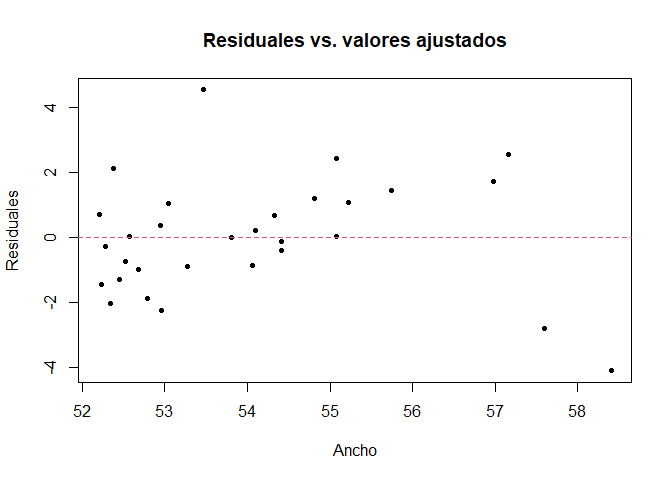

Continuamos ahora realizando el **diagnóstico analítico**. El primer paso es obtener los residuos, valores ajustados y estadísticos del modelo analizado para poder así estudiar si se cumplen los supuestos del mismo.

**Obtención de residuos, valores ajustados y estadísticos necesarios**

Para ello, añadimos los correspondientes resultados a nuestros datos a través del siguiente código:

El resultado es la creación de las siguientes variables:

- `fitted.modelo1`: valores ajustados (valores de la variable respuesta) para las observaciones originales de la predictora.
- `residuals.modelo1`: residuos del modelo, esto es, diferencia entre valor observado de la respuesta y valor ajustado por el modelo.
- `rstudent.modelo1`: residuos estudentizados del modelo ajustado.

Vamos a utilizar todas estas variables para estudiar si nuestro modelo cumple las hipótesis.

Empezamos el análisis con un gráfico `qqplot`, que enfrenta los valores reales a los valores que obtendríamos si la distribución fuera normal. Si los datos reales se distribuyen normalmente, estos tendrán la misma distribución que los valores esperados y en el gráfico `qqplot` obtendremos una línea recta en la diagonal.

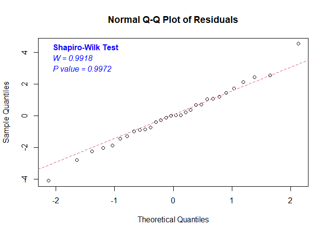

Podemos ver que nuestro $p-valor > 0.05$ por lo que no se rechaza la hipótesis nula donde los datos se distribuyen normal. además por medio de la gráfica nos muestra como nuestros puntos se acomodan bien a la recta.

```
##
##  studentized Breusch-Pagan test
##
## data:  modelo1
## BP = 4.5466, df = 1, p-value = 0.03298
```

No Existe homogeneidad pues la significación es menor de 0.05, la varianza no es constante a lo largo de la muestra.

# Transformación del Modelo

Dado que nuestra varianza no es constante, tendremos que hacer una transformación en nuestro modelo, es decir: $Y^* = log(Y) \ \wedge \ X^* = log(X)$

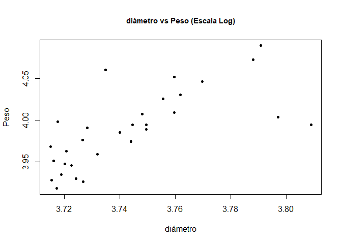

Como podemos ver los datos si tienen en algún grado una correlación positiva (mientras aumentan los valores del diámetro aumenta el peso) a priori.

Una vez visto que existe relación entre las variables pasamos a realizar el ajuste del modelo. Para ello usamos la función `lm(log())` *(log() <- logaritmo neperiano)* que toma la forma:

```
##
## Call:
## lm(formula = log(peso) ~ log(diametro), data = datos)
##
## Residuals:
##       Min        1Q    Median        3Q       Max
## -0.073651 -0.017460  0.000711  0.020168  0.082143
##
## Coefficients:
##               Estimate Std. Error t value Pr(>|t|)
## (Intercept)    -0.5532     0.8645  -0.640    0.527
## log(diametro)   1.2133     0.2309   5.254 1.38e-05 ***
## ---
## Signif. codes:  0 '***' 0.001 '**' 0.01 '*' 0.05 '.' 0.1 ' ' 1
##
## Residual standard error: 0.03292 on 28 degrees of freedom
## Multiple R-squared:  0.4965, Adjusted R-squared:  0.4785
## F-statistic: 27.61 on 1 and 28 DF,  p-value: 1.385e-05
```

Como podemos ver nuestro intercepto dado el $p-valor > 0.05$ decimos que el intercepto tengan valor a cero, esto es lógico ya que sería extraño encontrar huevos con diametro cero y un valor de peso inicial.

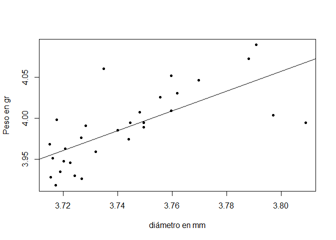

En primer lugar deseamos obtener los estimadores puntuales, errores estándar y p-valores asociados con cada coeficiente

```
##                 Estimate Std. Error    t value     Pr(>|t|)
## (Intercept)   -0.5531989  0.8644818 -0.6399197 5.274268e-01
## log(diametro)  1.2133149  0.2309251  5.2541481 1.384744e-05
```

El resultado del ajuste es:

`(0.8644818)` `(0.2309251)`

$log(Peso) \ = \ 0 + 1.2133149*log(diámetro)$

## Intervalos de Confianza

Obtenemos los correspondientes intervalos de confianza para el parámetro $m$ de nuestras modelo = $Y^* = 0+m*X^*$ con nivel significación al 95%

| Parámetro | 2.5 % | 97.5 % |
| --- | --- | --- |
| $log(diametro)$ | 0.74028 | 1.686344 |

**Interpretamos los intervalos:** con una probabilidad del 95%, el efecto asociado con diametro se encuentra en el intervalo $(0.7402862, 1.686344)$.

## Tabla ANOVA

Obtenemos la correspondiente tabla ANOVA donde vemos la descomposición de la variabilidad del modelo

|  | Df | Sum Sq | Mean Sq | F value | Pr(>F) |
| --- | --- | --- | --- | --- | --- |
| log(diametro) | 1 | 0.0299145 | 0.0299145 | 27.60607 | 1.38e-05 |
| Residuals | 28 | 0.0303414 | 0.0010836 | NA | NA |

Observamos que la variabilidad explicada por el modelo, `SSM=0.029915`, es inferior a la que queda por explicar (residuos), `SSR=0.030341` y el estadístico `F=27.606`, mayor que 1. Además, volviendo a ver el resumen del modelo

`## F-statistic: 27.606 on 1 and 28 DF, p-value: 1.385e-05`

tenemos que el $p-valor$ asociado con el estadístico F es inferior a 0.05.

La conclusión es que hay evidencias suficientes para poder rechazar la hipótesis nula, $H_0: F=1$ y por tanto, resulta posible establecer un modelo de regresión lineal para explicar el comportamiento del peso de un huevo en función de su diámetro.

# Análisis de los parámetros del modelo

El test ANOVA significativo nos dice si el modelo tiene, en general, un grado de predicción significativamente bueno para la variable resultado, pero no nos dice nada sobre la contribución individual del modelo. Para encontrar los parámetros del modelo y su significación tenemos que volver a la parte `Coefficients` en el resumen del modelo.

| $\beta_1$ | Estimate | Std. Error | t value | $Pr(>\|t\|)$ |
| --- | --- | --- | --- | --- |
| log(diametro) | 1.2133149 | 0.2309251 | 5.2541481 | 1.384744e-05 |

Observando la tabla vemos que $\beta_1$ es la pendiente de la recta y representa el cambio en la variable dependiente (peso) asociado al cambio de una unidad en la variable predictora. Si nuestra variable predictora incrementa una unidad, nuestro modelo predice que el peso de un huevo se incrementará en $1.213 \ gr$, pues en este caso $\beta_1 = 1.213$ Por tanto, la ecuación del modelo queda:

$Y = 0 + 1.213*X$

# Diagnóstico del modelo

En este apartado hemos hecho uso tanto de *J.Faraway (2009)* como de *Sánchez (2011)* para el desarrollo del mismo.

Una vez que tenemos el modelo ajustado procedemos con su diagnóstico, que se realiza a través del **análisis de los residuos** $\varepsilon_i$:

- Las hipótesis de linealidad, homocedasticidad e independencia se contrastan a través de un análisis gráfico que enfrenta los valores de los residuos, $\varepsilon_i$, con los valores ajustados $\hat{x}_i$.
- Las hipótesis de media cero, varianza constante, incorrelación y normalidad la comprobamos analíticamente

Comenzaremos con el análisis gráfico. Los residuos deberían formar una nube de puntos sin estructura y con, aproximadamente, la misma variabilidad por todas las zonas como se muestra en el gráfico:

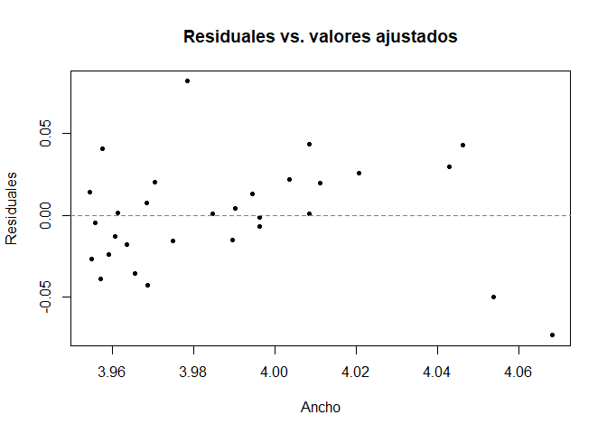

Continuamos ahora realizando el **diagnóstico analítico**. El primer paso es obtener los residuos, valores ajustados y estadísticos del modelo analizado para poder así estudiar si se cumplen los supuestos del mismo.

**Obtención de residuos, valores ajustados y estadísticos necesarios**

Para ello, añadimos los correspondientes resultados a nuestros datos a través del siguiente código:

El resultado es la creación de las siguientes variables:

- `fitted.modelo2`: valores ajustados (valores de la variable respuesta) para las observaciones originales de la predictora.
- `residuals.modelo2`: residuos del modelo, esto es, diferencia entre valor observado de la respuesta y valor ajustado por el modelo.
- `rstudent.modelo2`: residuos estudentizados del modelo ajustado.

Vamos a utilizar todas estas variables para estudiar si nuestro modelo cumple las hipótesis.

Empezamos el análisis con un gráfico `qqplot`, que enfrenta los valores reales a los valores que obtendríamos si la distribución fuera normal. Si los datos reales se distribuyen normalmente, estos tendrán la misma distribución que los valores esperados y en el gráfico `qqplot` obtendremos una linea recta en la diagonal.

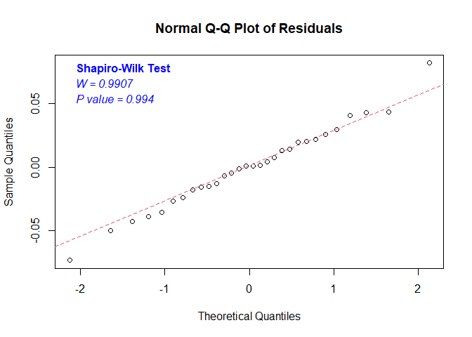

Aqui podemos ver que tambien se cumple el supuesto de normalidad, dejandonos con la siguiente pregunta: *¿ya que nuestros datos están transformados será que nuestra varianza será constante?*

```
##
##  studentized Breusch-Pagan test
##
## data:  modelo2
## BP = 3.7084, df = 1, p-value = 0.05414
```

Existe homogeneidad pues la significación es mayor de 0.05, la varianza es constante a lo largo de la muestra.

## Autocorrelación (test de Durbin-Watson)

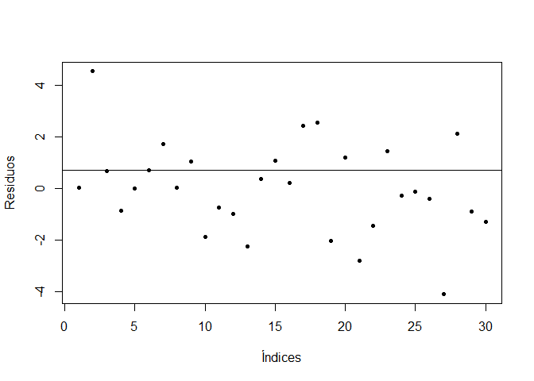

Si hubiera una correlación sería, veríamos picos más largos de residuos por encima y por debajo de la línea de correlación. A menos que estos efectos sean fuertes, puede ser difícil de detectar la autocorrelación, por ello realizamos el contraste de Durbin-Watson.

```
##
##  Durbin-Watson test
##
## data:  peso ~ diametro
## DW = 2.0779, p-value = 0.7969
## alternative hypothesis: true autocorrelation is not 0
```

En el contraste de autocorrelación también aceptamos la hipótesis nula de que no existe correlación entre los residuos con un $p-valor$ superior a 0.05.

# Predicción

Tenemos un modelo de regresión con la capacidad de relacionar la variable predictora y la variable dependiente. Podemos utilizarlo ahora para predecir eventos futuros de la variable dependiente a través de nuevos valores de la variable predictora.

Para ello debe verificarse alguna de las siguientes condiciones:

- el valor de la predictora está dentro del rango de la variable original.
- si el valor de la predictora está fuera del rango de la original, debemos asegurar que los valores futuros mantendrán el modelo lineal propuesto.

## Predicción de nuevas observaciones

Dibujamos las bandas de predicción, que reflejan la incertidumbre sobre futuras observaciones:

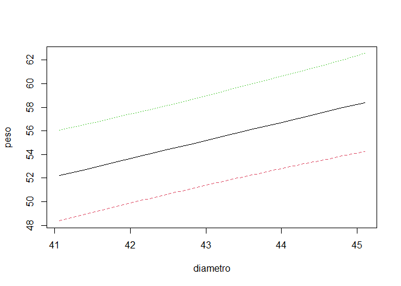

## Intervalos de confianza para los predictores:

Dado un nuevo conjunto de predictores, x0, debemos evaluar la incertidumbre en esta predicción. Para tomar decisiones racionales necesitamos algo más que puntos estimados. Si la predicción tiene intervalo de confianza ancho entonces entonces los resultados estarán lejos de la estimación puntual.

> Nota: Las bandas de confianza reflejan la incertidumbre en la línea de regresión (lo bien que la línea está calculada).

```
##        fit      lwr      upr
## 1 52.20622 51.21131 53.20113
## 2 52.64890 51.77438 53.52341
## 3 53.09157 52.31614 53.86700
## 4 53.53424 52.82755 54.24093
## 5 53.97692 53.29932 54.65451
## 6 54.41959 53.72644 55.11275
```

Dibujamos las bandas de confianza, que además reflejan la incertidumbre sobre futuras observaciones:

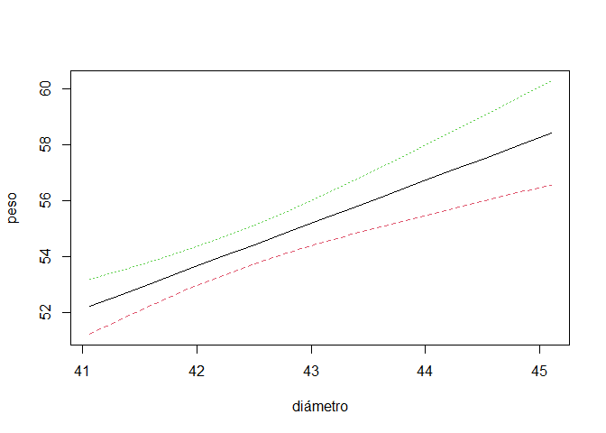

Por último podemos hacer un gráfico con la nube de puntos y los dos bandas, la de confianza y la de predicción *(Ferrari & Head, 2010)*.

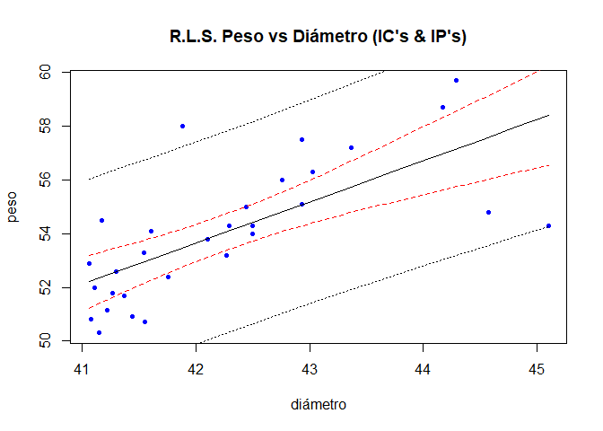

# Modelo N°2 (Peso~Altura)

## Ajuste del modelo:

Antes de observar o crear un modelo dado unos puntos, primero haremos un test de correlación de los datos para estudiar el grado de variación conjunta entre la altura y el peso de los huevos:

```
##
##  Pearson's product-moment correlation
##
## data:  datos$largo and datos$peso
## t = 2.4424, df = 28, p-value = 0.02116
## alternative hypothesis: true correlation is not equal to 0
## 95 percent confidence interval:
##  0.06926414 0.67711427
## sample estimates:
##       cor
## 0.4190759
```

Como podemos ver se rechaza $H_0$ ya que el $p-valor < 0.05$, es decir nuestros datos peso y el largo de los huevos tomados tienen una correlación significativa, es decir, una correlación positiva entre los datos, que vamos a ver por medio de un gráfico de dispersión:

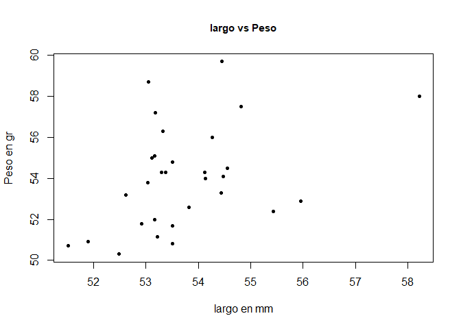

Como podemos ver los datos si tienen en algún grado una correlación positiva (mientras aumentan los valores del diámetro aumenta el peso) a priori.

Una vez visto que existe relación entre las variables pasamos a realizar el ajuste del modelo. Para ello usamos la función `lm()` que toma la forma:

```
##
## Call:
## lm(formula = peso ~ largo, data = datos)
##
## Residuals:
##     Min      1Q  Median      3Q     Max
## -3.0482 -1.5604 -0.1238  1.3495  5.2285
##
## Coefficients:
##             Estimate Std. Error t value Pr(>|t|)
## (Intercept)  10.0310    18.0260   0.556   0.5823
## largo         0.8189     0.3353   2.442   0.0212 *
## ---
## Signif. codes:  0 '***' 0.001 '**' 0.01 '*' 0.05 '.' 0.1 ' ' 1
##
## Residual standard error: 2.297 on 28 degrees of freedom
## Multiple R-squared:  0.1756, Adjusted R-squared:  0.1462
## F-statistic: 5.965 on 1 and 28 DF,  p-value: 0.02116
```

Como podemos ver nuestro intercepto dado el $p-valor > 0.05$ decimos que el intercepto tengan valor a cero, esto es lógico ya que sería extraño encontrar huevos con altura = cero y un valor de peso inicial.

[figure not shown]

En primer lugar deseamos obtener los estimadores puntuales, errores estándar y p-valores asociados con cada coeficiente

```
##               Estimate Std. Error   t value   Pr(>|t|)
## (Intercept) 10.0309793 18.0260060 0.5564726 0.58230836
## largo        0.8188604  0.3352747 2.4423569 0.02116101
```

El resultado del ajuste es:

`(18.0260060)` `(0.3352747)`

$Peso \ = \ 0 + 0.8188604*largo$

## Intervalos de Confianza

Obtenemos los correspondientes intervalos de confianza para el parámetro $m$ de nuestras modelo = $Y = 0+m*X$ con nivel significación al 95%

| Parámetro | 2.5 % | 97.5 % |
| --- | --- | --- |
| altura | 0.13208 | 1.505639 |

**Interpretamos los intervalos:** con una probabilidad del 95%, el efecto asociado con el largo se encuentra en el intervalo $(0.1320814, 1.505639)$.

## Tabla ANOVA

Obtenemos la correspondiente tabla ANOVA donde vemos la descomposición de la variabilidad del modelo

|  | Df | Sum Sq | Mean Sq | F value | Pr(>F) |
| --- | --- | --- | --- | --- | --- |
| largo | 1 | 31.48277 | 31.482768 | 5.965107 | 0.021161 |
| Residuals | 28 | 147.77898 | 5.277821 | NA | NA |

`## F-statistic: 5.9651 on 1 and 28 DF, p-value: 0.02116`

tenemos que el $p-valor$ asociado con el estadístico F es inferior a 0.05.

## Coeficiente de determinación

En el `modelo3` el valor de $R^2$ es `Multiple R-squared: 0.1756`, alrededor del 17.56% de la variabilidad del peso es explicada por la recta ajustada.

# Análisis de los parámetros del modelo

El test ANOVA significativo nos dice si el modelo tiene, en general, un grado de predicción significativamente bueno para la variable resultado, pero no nos dice nada sobre la contribución individual del modelo. Para encontrar los parámetros del modelo y su significación tenemos que volver a la parte `Coefficients` en el resumen del modelo.

| $\beta_1$ | Estimate | Std. Error | t value | $Pr(>\|t\|)$ |
| --- | --- | --- | --- | --- |
| largo | 0.8188604 | 0.3352747 | 2.4423569 | 0.02116101 |

Observando la tabla vemos que $\beta_1$ es la pendiente de la recta y representa el cambio en la variable dependiente (peso) asociado al cambio de una unidad en la variable predictora. Si nuestra variable predictora incrementa una unidad, nuestro modelo predice que el peso de un huevo se incrementará en $0.82 \ gr$, pues en este caso $\beta_1 = 0.82$ Por tanto, la ecuación del modelo queda:

$Y = 0 + 0.82*X$

# Diagnóstico del modelo

En este apartado hemos hecho uso tanto de J.Faraway (2009) como de Sánchez (2011) para el desarrollo del mismo.

Una vez que tenemos el modelo ajustado procedemos con su diagnóstico, que se realiza a través del **análisis de los residuos** $\varepsilon_i$:

- Las hipótesis de linealidad, homocedasticidad e independencia se contrastan a través de un análisis gráfico que enfrenta los valores de los residuos, $\varepsilon_i$, con los valores ajustados $\hat{x}_i$.
- Las hipótesis de media cero, varianza constante, incorrelación y normalidad la comprobamos analíticamente

Comenzaremos con el análisis gráfico. Los residuos deberían formar una nube de puntos sin estructura, para esto evaluaremos el siguiente gráfico:

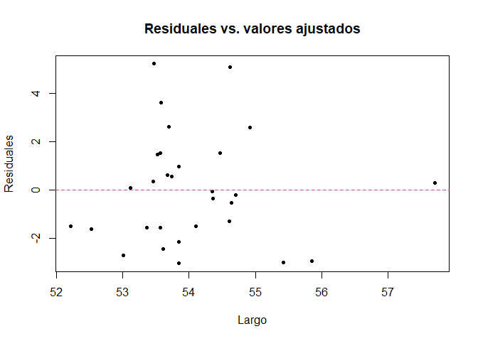

Continuamos ahora realizando el **diagnóstico analítico**. El primer paso es obtener los residuos, valores ajustados y estadísticos del modelo analizado para poder así estudiar si se cumplen los supuestos del mismo.

**Obtención de residuos, valores ajustados y estadísticos necesarios**

Para ello, añadimos los correspondientes resultados a nuestros datos a través del siguiente código:

El resultado es la creación de las siguientes variables:

- `fitted.modelo3`: valores ajustados (valores de la variable respuesta) para las observaciones originales de la predictora.
- `residuals.modelo3`: residuos del modelo, esto es, diferencia entre valor observado de la respuesta y valor ajustado por el modelo.
- `rstudent.modelo3`: residuos estudentizados del modelo ajustado.

Vamos a utilizar todas estas variables para estudiar si nuestro modelo cumple las hipótesis.

Empezamos el análisis con un gráfico `qqplot`, que enfrenta los valores reales a los valores que obtendríamos si la distribución fuera normal. Si los datos reales se distribuyen normalmente, estos tendrán la misma distribución que los valores esperados y en el gráfico `qqplot` obtendremos una linea recta en la diagonal.

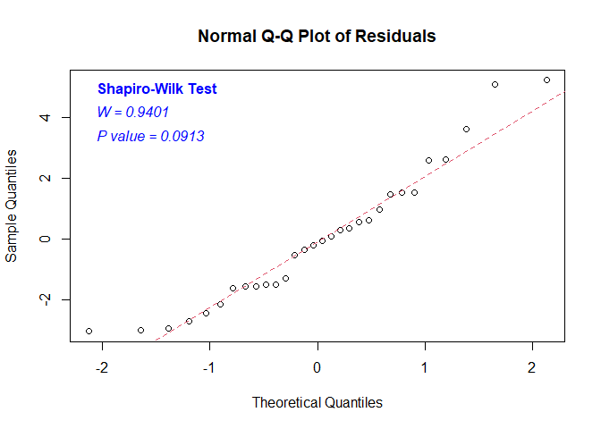

Podemos ver que nuestro $p-valor > 0.05$ por lo que no se rechaza la hipótesis nula donde los datos se distribuyen normal. además por medio de la gráfica nos muestra como nuestros puntos se acomodan bien a la recta.

```
##
##  studentized Breusch-Pagan test
##
## data:  modelo3
## BP = 0.00023802, df = 1, p-value = 0.9877
```

Existe homogeneidad pues la significación es mayor de 0.05, la varianza es constante a lo largo de la muestra.

## Autocorrelación (test de Durbin-Watson)

Hemos asumido que los residuos son incorrelados, vamos a comprobarlo.

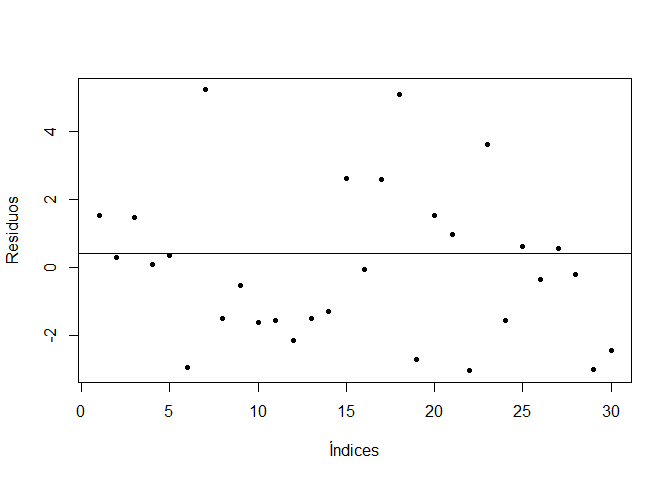

Si hubiera una correlación sería, veríamos picos más largos de residuos por encima y por debajo de la línea de correlación. A menos que estos efectos sean fuertes, puede ser difícil de detectar la autocorrelación, por ello realizamos el *contraste de Durbin-Watson*.

```
##
##  Durbin-Watson test
##
## data:  peso ~ largo
## DW = 2.3583, p-value = 0.3051
## alternative hypothesis: true autocorrelation is not 0
```

En el contraste de autocorrelación también aceptamos la hipótesis nula de que no existe correlación entre los residuos con un $p-valor$ superior a 0.05

## Valores atípicos:

Para observar si hay datos atípicos que hacen que nuestro modelo no sea el más óptimo. Vamos a realizar un test de valores atípicos (Bonferroni).

En el caso de observar valores atípicos los pasos a seguir son:

- Descartar que sea un error.
- Analizar si es un caso influyente.
- En caso de ser influyente calcular las rectas de regresión incluyéndolo y excluyéndolo, y elegir la que mejor se adapte al problema y a las observaciones futuras.

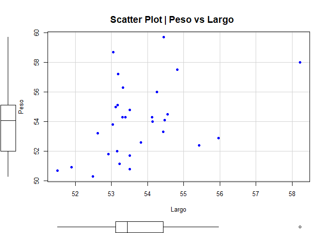

En la variable `largo` vemos que la mediana no está centrada en la media y contiene un valor atípico en la muestra, los datos no son uniformes. Con la variable `peso` ocurre casí lo mismo a excepción de ese dato atípico.

```
## No Studentized residuals with Bonferroni p < 0.05
## Largest |rstudent|:
##   rstudent unadjusted p-value Bonferroni p
## 7 2.544821           0.016962      0.50886
```

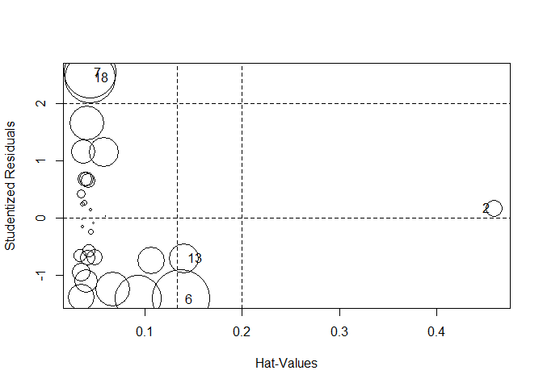

|  | StudRes | Hat | CookD |
| --- | --- | --- | --- |
| 2 | 0.1714820 | 0.4588309 | 0.0129136 |
| 6 | -1.4087161 | 0.1373254 | 0.1525856 |
| 7 | 2.5448208 | 0.0437795 | 0.1239995 |
| 13 | -0.7026427 | 0.1402320 | 0.0410043 |
| 18 | 2.4573114 | 0.0437596 | 0.1170944 |

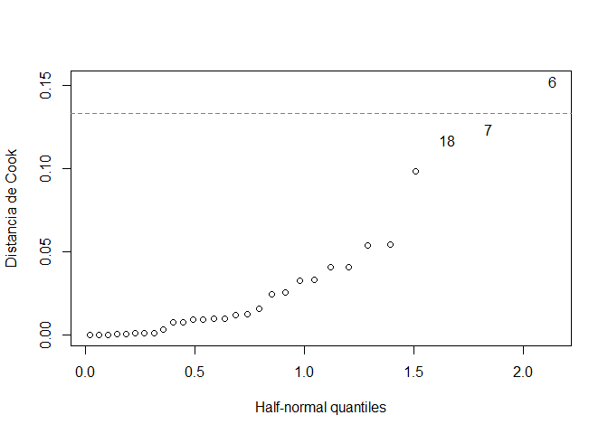

La linea roja representa el corte donde se puede observar si un dato influye o no dentro del modelo, pero con el gráfico de influencia nos muestra que la observación #6 no está alejada de los datos, por lo cual concluimos que no hay datos extraños o atípicos que afecten el modelo.

# Predicción

Tenemos un modelo de regresión con la capacidad de relacionar la variable predictora y la variable dependiente. Podemos utilizarlo ahora para predecir eventos futuros de la variable dependiente a través de nuevos valores de la variable predictora.

Para ello debe verificarse alguna de las siguientes condiciones:

1. El valor de la predictora está dentro del rango de la variable original.
2. Si el valor de la predictora está fuera del rango de la original, debemos asegurar que los valores futuros mantendrán el modelo lineal propuesto.

## Predicción de nuevas observaciones

```
##        fit      lwr      upr
## 1 52.21048 47.18543 57.23553
## 2 52.60295 47.66873 57.53717
## 3 52.99542 48.13140 57.85943
## 4 53.38788 48.57254 58.20323
## 5 53.78035 48.99151 58.56920
## 6 54.17282 49.38792 58.95772
```

aquí podemos ver según un largo dado en mm de un huevo cuál sera su intervalo de predicción de su peso en las dos columnas lower & upper.

Dibujamos las bandas de predicción, que reflejan la incertidumbre sobre futuras observaciones:

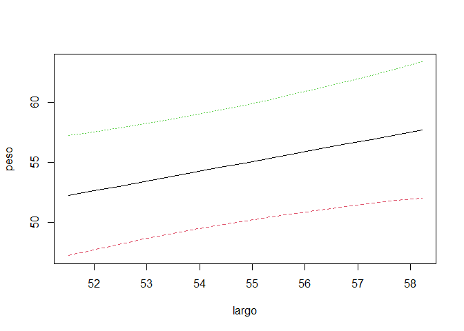

## Intervalos de confianza para los predictores

Además nosotros podemos tener un IC para nuestras `x` en este caso el largo, es decir, cuanto puede variar el largo de un huevo y según eso dar una estimación de su peso.

```
##        fit      lwr      upr
## 1 52.21048 50.44823 53.97273
## 2 52.60295 51.11939 54.08651
## 3 52.99542 51.76534 54.22549
## 4 53.38788 52.36714 54.40863
## 5 53.78035 52.89297 54.66774
## 6 54.17282 53.30698 55.03866
```

Dibujamos las bandas de confianza, que además reflejan la incertidumbre sobre futuras observaciones:

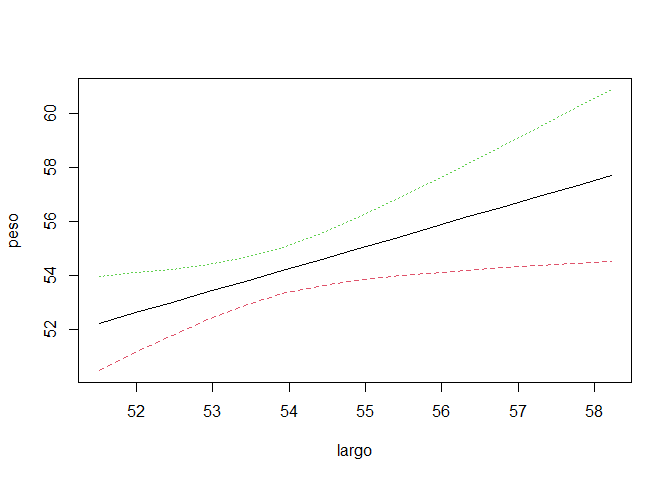

Por último podemos hacer un gráfico con la nube de puntos y las dos bandas, la de confianza y la de predicción (Ferrari & Head, 2010).

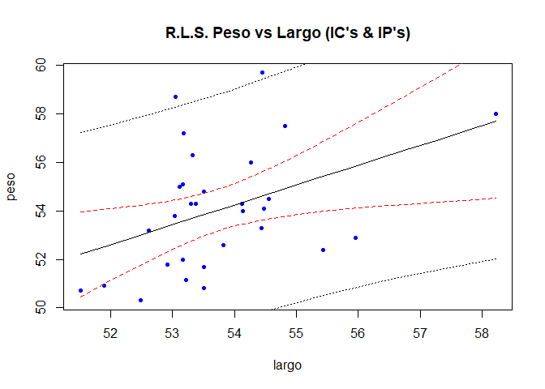

# Apéndice

## Codigo:

```
## ----message=FALSE, warning=FALSE, include=FALSE-----------------------
library(readr)
library(tidyverse)
library(kableExtra)
library(magrittr)
library(ggExtra)
library(GGally)
library(janitor)
library(tidystats)
library(car)
library(faraway)
library(lmtest)
library(graphics)
datos <- read_delim("eggs.csv", delim = ";") %>% clean_names()
names(datos)[3] <- "diametro"
myQQnorm <- function(modelo, student = F, ...){
  if(student){
    res <- rstandard(modelo)
    lab.plot <- "Normal Q-Q Plot of Studentized Residuals"
  } else {
    res <- residuals(modelo)
    lab.plot <- "Normal Q-Q Plot of Residuals"
  }
  shapiro <- shapiro.test(res)
  shapvalue <- ifelse(shapiro$p.value < 0.001, "P value < 0.001",
  paste("P value = ", round(shapiro$p.value, 4), sep = ""))
  shapstat <- paste("W = ", round(shapiro$statistic, 4), sep = "")
  q <- qqnorm(res, plot.it = FALSE)
  qqnorm(res, main = lab.plot, ...)
  qqline(res, lty = 2, col = 2)
  text(min(q$x, na.rm = TRUE), max(q$y, na.rm = TRUE)*0.95,
  pos = 4, 'Shapiro-Wilk Test', col = "blue", font = 2)
  text(min(q$x, na.rm = TRUE), max(q$y, na.rm = TRUE)*0.80,
  pos = 4, shapstat, col = "blue", font = 3)
  text(min(q$x, na.rm = TRUE), max(q$y, na.rm = TRUE)*0.65,
  pos = 4, shapvalue, col = "blue", font = 3)
}
## ----echo=FALSE, message=FALSE, warning=FALSE--------------------------
cor.test(datos$diametro, datos$peso)
## ----echo=FALSE, message=FALSE, warning=FALSE--------------------------
plot(datos$diametro, datos$peso, xlab = "diámetro en mm",
     ylab = "Peso en gr", main = "diámetro vs Peso",
     cex.main = 0.95, pch=20)
## ----echo=FALSE, message=FALSE, warning=FALSE--------------------------
modelo1 <- lm(peso~diametro, data=datos)
summary(modelo1)
## ----echo=FALSE, message=FALSE, warning=FALSE--------------------------
plot(datos$diametro, datos$peso, xlab = "diámetro en mm",
     ylab = "Peso en gr", pch=20)
abline(modelo1)
## ----echo=FALSE, message=FALSE, warning=FALSE--------------------------
summary(modelo1)$coefficients
## ----message=FALSE, warning=FALSE, include=FALSE-----------------------
MSR.ancho <- mean(summary(modelo1)$residuals^2)
## ----message=FALSE, warning=FALSE, include=FALSE-----------------------
confint(modelo1, level = 0.95)
## ----echo=FALSE, message=FALSE, warning=FALSE--------------------------
anova(modelo1)
## ----echo=FALSE, message=FALSE, warning=FALSE--------------------------
plot(fitted(modelo1), residuals(modelo1), xlab = "Ancho",
ylab = "Residuales", main = "Residuales vs. valores ajustados",pch=20)
abline(h = 0, lty = 2, col = 2)
## ----message=FALSE, warning=FALSE, include=FALSE-----------------------
datos$fitted.modelo1 <- fitted(modelo1)
datos$residuals.modelo1 <- residuals(modelo1)
datos$rstudent.modelo1 <- rstudent(modelo1)
## ----echo=FALSE, message=FALSE, warning=FALSE--------------------------
modelo1 %>% myQQnorm()
## ----echo=FALSE, message=FALSE, warning=FALSE--------------------------
bptest(modelo1)
## ----echo=FALSE, message=FALSE, warning=FALSE--------------------------
plot(log(datos$diametro), log(datos$peso), xlab = "diámetro",
     ylab = "Peso", main = "diámetro vs Peso (Escala Log)",
     cex.main = 0.95, pch=20)
## ----echo=FALSE, message=FALSE, warning=FALSE--------------------------
modelo2 <- lm(log(peso)~log(diametro), data=datos)
summary(modelo2)
## ----echo=FALSE, message=FALSE, warning=FALSE--------------------------
plot(log(datos$diametro), log(datos$peso), xlab = "diámetro en mm",
     ylab = "Peso en gr", pch=20)
abline(modelo2)
## ----echo=FALSE, message=FALSE, warning=FALSE--------------------------
summary(modelo2)$coefficients
## ----message=FALSE, warning=FALSE, include=FALSE-----------------------
MSR.log.ancho <- mean(summary(modelo2)$residuals^2)
## ----message=FALSE, warning=FALSE, include=FALSE-----------------------
confint(modelo2, level = 0.95)
## ----echo=FALSE, message=FALSE, warning=FALSE--------------------------
anova(modelo2)
## ----echo=FALSE, message=FALSE, warning=FALSE--------------------------
plot(fitted(modelo2), residuals(modelo2), xlab = "Ancho",
ylab = "Residuales", main = "Residuales vs. valores ajustados",pch=20)
abline(h = 0, lty = 2, col = 2)
## ----message=FALSE, warning=FALSE, include=FALSE-----------------------
datos$fitted.modelo2 <- fitted(modelo2)
datos$residuals.modelo2 <- residuals(modelo2)
datos$rstudent.modelo2 <- rstudent(modelo2)
## ----echo=FALSE, message=FALSE, warning=FALSE--------------------------
modelo2 %>% myQQnorm()
## ----echo=FALSE, message=FALSE, warning=FALSE--------------------------
bptest(modelo2)
## ----echo=FALSE, message=FALSE, warning=FALSE--------------------------
plot(datos$residuals.modelo1, pch = 20,
     ylab = "Residuos", xlab = "Índices")
abline(h = cor(datos$peso, datos$diametro))
## ----------------------------------------------------------------------
dwtest(peso~diametro, alternative = "two.sided", data = datos)
## ----message=FALSE, warning=FALSE, include=FALSE-----------------------
x0 <- seq(min(datos$diametro), max(datos$diametro), length = 15)
dfp <- data.frame(diametro = x0)
pred.ip <- predict(modelo1, dfp, interval = "prediction", se.fit = TRUE, data = datos)
head(pred.ip$fit)
## ----------------------------------------------------------------------
matplot(x0, pred.ip$fit, type = "l", xlab = "diametro", ylab = "peso")
## ----message=FALSE, warning=FALSE, include=FALSE-----------------------
x0 <- seq(min(datos$diametro), max(datos$diametro), length = 15)
dfp <- data.frame(diametro = x0)
pred.ip <- predict(modelo2, dfp, interval = "prediction",
se.fit = TRUE, data = datos)
pred.ip1 <- predict(modelo1, dfp, interval = "prediction",
se.fit = TRUE, data = datos)
head(pred.ip$fit)
newpred <- exp(pred.ip$fit)
head(newpred)
## ----------------------------------------------------------------------
pred.ic <- predict(modelo1, dfp, interval = "confidence",
se.fit = TRUE, data = datos)
head(pred.ic$fit)
## ----------------------------------------------------------------------
matplot(x0, pred.ic$fit, type = "l", xlab = "diametro", ylab = "peso")
## ----------------------------------------------------------------------
plot(datos$diametro, datos$peso, pch = 20, xlab = "diametro",
ylab = "peso", col="blue")
# Añadimos las bandas
matlines(dfp$diametro, pred.ic$fit, lty = c(1, 2, 2),
         lwd = 1.5, col = "red")
matlines(dfp$diametro, pred.ip1$fit, lty = c(1, 3, 3),
         lwd = 1.5, col= "black")
title(main= "R.L.S. Peso vs Diámetro (IC's & IP's)")
## ----echo=FALSE, message=FALSE, warning=FALSE--------------------------
cor.test(datos$largo, datos$peso)
## ----echo=FALSE, message=FALSE, warning=FALSE--------------------------
plot(datos$largo, datos$peso, xlab = "largo en mm",
     ylab = "Peso en gr", main = "largo vs Peso",
     cex.main = 0.95, pch=20)
## ----echo=FALSE, message=FALSE, warning=FALSE--------------------------
modelo3 <- lm(peso~largo, data=datos)
summary(modelo3)
## ----echo=FALSE, message=FALSE, warning=FALSE--------------------------
plot(datos$largo, datos$peso, xlab = "diámetro en mm",
     ylab = "Peso en gr", pch=20)
abline(modelo3)
## ----echo=FALSE, message=FALSE, warning=FALSE--------------------------
summary(modelo3)$coefficients
## ----message=FALSE, warning=FALSE, include=FALSE-----------------------
MSR.largo <- mean(summary(modelo3)$residuals^2)
## ----message=FALSE, warning=FALSE, include=FALSE-----------------------
confint(modelo3, level = 0.95)
## ----echo=FALSE, message=FALSE, warning=FALSE--------------------------
anova(modelo3)
## ----echo=FALSE, message=FALSE, warning=FALSE--------------------------
plot(fitted(modelo3), residuals(modelo3), xlab = "Largo",
ylab = "Residuales", main = "Residuales vs. valores ajustados",pch=20)
abline(h = 0, lty = 2, col = 2)
## ----message=FALSE, warning=FALSE, include=FALSE-----------------------
datos$fitted.modelo3 <- fitted(modelo3)
datos$residuals.modelo3 <- residuals(modelo3)
datos$rstudent.modelo3 <- rstudent(modelo3)
## ----echo=FALSE, message=FALSE, warning=FALSE--------------------------
modelo3 %>% myQQnorm()
## ----echo=FALSE, message=FALSE, warning=FALSE--------------------------
bptest(modelo3)
## ----echo=FALSE, message=FALSE, warning=FALSE--------------------------
plot(datos$residuals.modelo3, pch = 20, ylab = "Residuos", xlab = "Índices")
abline(h = cor(datos$peso , datos$largo))
## ----echo=FALSE, message=FALSE, warning=FALSE--------------------------
dwtest(peso~largo, alternative = "two.sided", data = datos)
## ----echo=FALSE, message=FALSE, warning=FALSE--------------------------
scatterplot(peso~largo,data = datos,smooth = F, pch=19,
            regLine = F, xlab = "Largo", ylab = "Peso")
title(main = "Scatter Plot | Peso vs Largo")
## ----echo=FALSE, message=FALSE, warning=FALSE--------------------------
outlierTest(modelo3, cutoff = 0.05, n.max = 10, order = TRUE)
influencePlot(modelo3, id.n = 2)
## ----echo=FALSE, message=FALSE, warning=FALSE--------------------------
cook3 <- cooks.distance(modelo3)
labels3 <- rownames(datos)
halfnorm(cook, 3, labs = labels, ylab = "Distancia de Cook")
abline(h=4/30, lty = 2, col = 2)
## ----echo=FALSE, message=FALSE, warning=FALSE--------------------------
x0.l <- seq(min(datos$largo), max(datos$largo), length = 15)
dfp.l <- data.frame(largo = x0.l)
pred.ip.l <- predict(modelo3, dfp.l, interval = "prediction",
                     se.fit =TRUE, data = datos)
head(pred.ip.l$fit)
## ----echo=FALSE, message=FALSE, warning=FALSE--------------------------
matplot(x0.l, pred.ip.l$fit, type = "l", xlab = "largo", ylab = "peso")
## ----echo=FALSE, message=FALSE, warning=FALSE--------------------------
pred.ic.l <- predict(modelo3, dfp.l, interval = "confidence",
se.fit = TRUE, data = datos)
head(pred.ic.l$fit)
## ----------------------------------------------------------------------
matplot(x0.l, pred.ic.l$fit, type = "l", xlab = "largo", ylab = "peso")
## ----------------------------------------------------------------------
plot(datos$largo, datos$peso, pch = 20, xlab = "largo",
ylab = "peso", col="blue")
# Añadimos las bandas
matlines(dfp.l$largo, pred.ic.l$fit, lty = c(1, 2, 2),
         lwd = 1.5, col = "red")
matlines(dfp.l$largo, pred.ip.l$fit, lty = c(1, 3, 3),
         lwd = 1.5, col= "black")
title(main= "R.L.S. Peso vs Largo (IC's & IP's)")
```

# Referencias

**[1]** Coleman, D. E., & Montgomery, D. C. (1993). A Systematic Approach to Planning for a Designed Industrial Experiment. Technometrics, 35(1), 1–12. https://doi.org/10.2307/1269280

**[2]** The jamovi project (2021). jamovi. (Version 2.2) [Computer Software]. Retrieved from https://www.jamovi.org.

**[3]** R Core Team (2021). R: A Language and environment for statistical computing. (Version 4.0) [Computer software]. Retrieved from https://cran.r-project.org. (R packages retrieved from MRAN snapshot 2021-04-01).

**[4]** Fox, J., & Weisberg, S. (2020). car: Companion to Applied Regression. [R package]. Retrieved from https://cran.r-project.org/package=car.

**[5]** Ali S. Hadi, S. C. &. (2006). Linear models with r (4th edition.). John Wiley & Sons. Retrieved from http://samples.sainsburysebooks.co.uk/9780470055458_sample_381725.pdf

**[6]** Ferrari, D., & Head, T. (2010). Regression in r. part i: Simple linear regression. UCLA Department of Statistics Statistical Consulting Center. Retrieved October 13, 2014, from http://scc.stat.ucla.edu/page_attachments/0000/0139/reg_1.pdf

**[7]** Field, A., Miles, J., & Field, Z. (2012). Discovering statistics using r (1st edition.). Sage Publications Ltd.

**[8]** J.Faraway, J. (2009). Linear models with r (1st edition.). Taylor & Francis e-Library. Retrieved from http://home.ufam.edu.br/jcardoso/PPGMAT537/Linear%20Models%20with%20R.pdf

**[9]** Kabacoff, R. (2014). Creating a figure arrangement with fine control. Retrieved October 13, 2014, from http://www.statmethods.net/advgraphs/layout.html

**[10]** Pérez, J. L. (2014). La estadística: Una orqueta hecha instrumento. Retrieved October 13, 2014, from http://estadisticaorquestainstrumento.wordpress.com/

**[11]** Sánchez, J. G. P. (2011). Regresión lineal simple. Universidad Politécnica de Madrid. Retrieved October 13, 2014, from http://ocw.upm.es/estadistica-e-investigacion-operativa/introduccion-a-la-estadistica-basica-el-diseno-de-experimentos-y-la-regresion-lineal/contenidos/Material-de-clase/Regresion.pdf

**[12]** (SCG), S. S. C. G. (2013). Multiple linear regression (r). San Diego State University. Retrieved October 13, 2014, from http://scg.sdsu.edu/mlr-r/

**[13]** SPSS. (2007). Análisis de regresión lineal: El procedimiento regresión lineal. IBM SPSS Statistics. Retrieved October 13, 2014, from http://pendientedemigracion.ucm.es/info/socivmyt/paginas/D_departamento/materiales/analisis_datosyMultivariable/18reglin_SPSS.pdf